# AlgoTrading

```python
import pandas as pd
from google.colab import drive
from statsmodels.multivariate import pca
import matplotlib.pyplot as plt
import numpy as np
from scipy.optimize import minimize
import scipy.optimize as sco
import matplotlib.pyplot as plt
import matplotlib.ticker as mtkr
import matplotlib.dates as mdts

import statsmodels.api as sm
drive.mount('/content/drive')
```

### Algorithmic Trading project A5 ESILV

CABAL Paul-Louis

```python
MA=pd.read_csv("/content/drive/MyDrive/ESILV/Trading Algo/projet/Multi-asset PCA_CHANGES=4w.csv", index_col= 0)
MA
```

|  | MSCI World | S&P 500 | Euro Stoxx 50 | Euro Stoxx Banks | CDX.IG 5Y | CDX.HY 5Y | iTraxx Europe 5Y | iTraxx Crossover 5Y | Italy - Germany 10Y | US 2Y | ... | USD 3M x 10Y ATM vol. | USD 1Y x 10Y ATM vol. | USD 5Y x 5Y ATM vol. | USD 10Y x 20Y ATM vol. | US Govt. | European Govt. | US Corp. Bonds | European Corp. Bonds | US High Yield | European High Yield |
| --- | --- | --- | --- | --- | --- | --- | --- | --- | --- | --- | --- | --- | --- | --- | --- | --- | --- | --- | --- | --- | --- |
| 2005-06-10 | 0.012532 | 0.022793 | 0.056718 | 0.047424 | 0.006602 | 0.026766 | 0.006048 | 0.035003 | 4.9 | 1.65 | ... | 0.00 | -0.400 | 2.65 | -0.15 | 0.010386 | 0.017674 | 0.013421 | 0.019308 | 0.029171 | 0.029893 |
| 2005-07-06 | 0.002255 | -0.002649 | 0.025209 | 0.017424 | -0.000800 | 0.006752 | 0.001608 | 0.012723 | 0.9 | 7.43 | ... | 0.95 | 0.950 | -2.10 | -1.80 | 0.001192 | -0.004078 | 0.002829 | -0.002100 | 0.009255 | 0.009683 |
| 2005-08-03 | 0.046502 | 0.041080 | 0.036400 | 0.041141 | 0.003598 | 0.018337 | 0.001442 | 0.003727 | -2.9 | 24.17 | ... | 0.15 | -1.150 | -2.55 | -2.20 | -0.008140 | -0.005336 | -0.004783 | -0.005385 | 0.015161 | 0.014480 |
| 2005-08-31 | -0.008268 | -0.020054 | -0.024171 | -0.019341 | 0.001110 | -0.003190 | 0.000003 | 0.002291 | 1.6 | -19.54 | ... | -2.95 | 0.600 | 1.95 | 2.75 | 0.016193 | 0.015940 | 0.016234 | 0.016116 | 0.003449 | 0.007675 |
| 2005-09-27 | 0.010540 | -0.003834 | 0.036243 | 0.042163 | 0.000609 | -0.001547 | 0.001839 | 0.008034 | -0.1 | 25.54 | ... | -0.05 | -0.750 | -0.70 | 0.35 | -0.011720 | 0.000517 | -0.014359 | -0.000039 | -0.009020 | 0.001002 |
| ... | ... | ... | ... | ... | ... | ... | ... | ... | ... | ... | ... | ... | ... | ... | ... | ... | ... | ... | ... | ... | ... |
| 2022-11-30 | 0.084752 | 0.081787 | 0.090406 | 0.073881 | 0.007581 | 0.030603 | 0.009734 | 0.036006 | -20.9 | -30.95 | ... | -14.10 | -4.654 | -2.90 | -2.30 | 0.026953 | 0.022098 | 0.047535 | 0.025662 | 0.021258 | 0.032360 |
| 2022-12-28 | -0.055047 | -0.075548 | -0.040116 | 0.012875 | -0.003171 | -0.014656 | 0.000119 | -0.004665 | 17.9 | 4.10 | ... | 4.60 | 3.006 | 2.50 | 2.00 | -0.006943 | -0.045961 | -0.006454 | -0.019763 | -0.006197 | -0.008446 |
| 2023-01-25 | 0.068134 | 0.059766 | 0.085333 | 0.101296 | 0.006157 | 0.028027 | 0.006219 | 0.024940 | -33.4 | -22.62 | ... | -17.90 | -21.406 | -14.50 | -5.50 | 0.028097 | 0.030792 | 0.041032 | 0.027126 | 0.035909 | 0.029603 |
| 2023-02-22 | -0.009421 | -0.006287 | 0.022589 | 0.063275 | -0.001573 | -0.007013 | 0.000186 | 0.003366 | 15.3 | 56.83 | ... | 2.40 | 3.907 | 4.30 | 3.40 | -0.025541 | -0.026568 | -0.031878 | -0.012932 | -0.019851 | 0.002439 |
| 2023-03-22 | -0.016522 | -0.013643 | -0.011182 | -0.096528 | -0.000676 | -0.013304 | -0.000156 | -0.002206 | -9.9 | -75.66 | ... | 9.20 | 1.447 | 2.70 | -1.10 | 0.029796 | 0.014531 | 0.023493 | -0.000127 | 0.005266 | -0.009522 |

232 rows × 40 columns

• Make the PCA of the factors in Multi-asset PCA CHANGES=4w.csv

```python
MA_normalised = (MA - MA.mean()) / MA.std()
MA_normalised
```

|  | MSCI World | S&P 500 | Euro Stoxx 50 | Euro Stoxx Banks | CDX.IG 5Y | CDX.HY 5Y | iTraxx Europe 5Y | iTraxx Crossover 5Y | Italy - Germany 10Y | US 2Y | ... | USD 3M x 10Y ATM vol. | USD 1Y x 10Y ATM vol. | USD 5Y x 5Y ATM vol. | USD 10Y x 20Y ATM vol. | US Govt. | European Govt. | US Corp. Bonds | European Corp. Bonds | US High Yield | European High Yield |
| --- | --- | --- | --- | --- | --- | --- | --- | --- | --- | --- | --- | --- | --- | --- | --- | --- | --- | --- | --- | --- | --- |
| 2005-06-10 | 0.167450 | 0.343277 | 1.016358 | 0.552594 | 1.021668 | 0.940069 | 0.834451 | 1.310608 | 0.148132 | 0.072246 | ... | -0.012515 | -0.059194 | 0.499113 | -0.047339 | 0.637123 | 1.088591 | 0.489450 | 1.186558 | 0.785765 | 0.764510 |
| 2005-07-06 | -0.027851 | -0.153893 | 0.436512 | 0.233379 | -0.263237 | 0.130086 | 0.121136 | 0.364581 | 0.006282 | 0.343949 | ... | 0.066179 | 0.112389 | -0.404934 | -0.546551 | -0.067827 | -0.391676 | -0.009991 | -0.261775 | 0.146020 | 0.152702 |
| 2005-08-03 | 0.812959 | 0.700608 | 0.642461 | 0.485735 | 0.500203 | 0.598946 | 0.094529 | -0.017407 | -0.128475 | 1.130855 | ... | -0.000089 | -0.154518 | -0.490581 | -0.667572 | -0.783406 | -0.477266 | -0.368965 | -0.483981 | 0.335740 | 0.297913 |
| 2005-08-31 | -0.227815 | -0.494001 | -0.472199 | -0.157813 | 0.068151 | -0.272288 | -0.136733 | -0.078345 | 0.031106 | -0.923843 | ... | -0.256881 | 0.067905 | 0.365885 | 0.830064 | 1.082408 | 0.970536 | 0.622093 | 0.970584 | -0.040484 | 0.091916 |
| 2005-09-27 | 0.129590 | -0.177045 | 0.639576 | 0.496616 | -0.018805 | -0.205800 | 0.158257 | 0.165498 | -0.029180 | 1.195255 | ... | -0.016656 | -0.103678 | -0.138478 | 0.103937 | -1.057891 | -0.078988 | -0.820468 | -0.122343 | -0.441008 | -0.110103 |
| ... | ... | ... | ... | ... | ... | ... | ... | ... | ... | ... | ... | ... | ... | ... | ... | ... | ... | ... | ... | ... | ... |
| 2022-11-30 | 1.539804 | 1.496070 | 1.636306 | 0.834108 | 1.191457 | 1.095391 | 1.426497 | 1.353180 | -0.766798 | -1.460199 | ... | -1.180501 | -0.599871 | -0.557195 | -0.697827 | 1.907484 | 1.389646 | 2.098054 | 1.616380 | 0.531607 | 0.839217 |
| 2022-12-28 | -1.116731 | -1.578400 | -0.765623 | 0.184979 | -0.674976 | -0.736341 | -0.118090 | -0.373734 | 0.609143 | 0.187414 | ... | 0.368531 | 0.373703 | 0.470564 | 0.603149 | -0.691614 | -3.241830 | -0.447752 | -1.456655 | -0.350336 | -0.396110 |
| 2023-01-25 | 1.224006 | 1.065746 | 1.542955 | 1.125815 | 0.944331 | 0.991104 | 0.861899 | 0.883335 | -1.210078 | -1.068626 | ... | -1.495278 | -2.729024 | -2.764973 | -1.665996 | 1.995159 | 1.981227 | 1.791424 | 1.715428 | 1.002223 | 0.755746 |
| 2023-02-22 | -0.249724 | -0.224972 | 0.388311 | 0.721253 | -0.397561 | -0.426986 | -0.107307 | -0.032696 | 0.516941 | 2.666119 | ... | 0.186292 | 0.488219 | 0.813150 | 1.026723 | -2.117699 | -1.922162 | -1.646589 | -0.994542 | -0.788922 | -0.066579 |
| 2023-03-22 | -0.384663 | -0.368717 | -0.233170 | -0.979117 | -0.241827 | -0.681624 | -0.162214 | -0.269298 | -0.376711 | -3.561904 | ... | 0.749576 | 0.175557 | 0.508629 | -0.334764 | 2.125446 | 0.874675 | 0.964376 | -0.128285 | 0.017894 | -0.428692 |

232 rows × 40 columns

```python
pca_model = pca.PCA(data=MA_normalised.values, standardize=True, normalize=False)
loadings = pca_model.loadings
scores = pca_model.scores
```

• Display the loadings of the first 6 Components (PC1, PC2 ... PC6)

```python
n_components = 6

loadings_df = pd.DataFrame(
    index=MA_normalised.columns,
    columns=[' '.join(['PC', str(j + 1)]) for j in range(n_components)],
    data=loadings[:, :n_components])

format_colour = lambda x: 'color:red' if x < 0 else 'color:green'
loadings_df.style.format(formatter='{:+.2f}').applymap(func=format_colour)
```

|  | PC 1 | PC 2 | PC 3 | PC 4 | PC 5 | PC 6 |
| --- | --- | --- | --- | --- | --- | --- |
| MSCI World | -0.25 | -0.05 | -0.07 | +0.02 | -0.08 | +0.12 |
| S&P 500 | -0.24 | -0.05 | -0.01 | +0.03 | -0.07 | +0.15 |
| Euro Stoxx 50 | -0.23 | -0.01 | +0.02 | +0.03 | -0.22 | +0.06 |
| Euro Stoxx Banks | -0.20 | +0.05 | -0.03 | -0.03 | -0.26 | -0.06 |
| CDX.IG 5Y | -0.23 | -0.01 | +0.06 | -0.00 | -0.21 | +0.04 |
| CDX.HY 5Y | -0.24 | -0.03 | +0.04 | +0.05 | -0.14 | +0.12 |
| iTraxx Europe 5Y | -0.22 | +0.01 | +0.08 | +0.06 | -0.27 | -0.13 |
| iTraxx Crossover 5Y | -0.23 | +0.00 | +0.07 | +0.12 | -0.16 | -0.02 |
| Italy - Germany 10Y | +0.09 | -0.03 | +0.05 | -0.04 | +0.35 | +0.53 |
| US 2Y | -0.10 | +0.25 | +0.16 | -0.11 | +0.04 | +0.13 |
| US 5Y | -0.10 | +0.30 | +0.12 | -0.02 | -0.01 | +0.11 |
| US 10Y | -0.09 | +0.31 | +0.07 | +0.04 | -0.04 | +0.04 |
| Germany 2Y | -0.10 | +0.23 | -0.14 | -0.17 | +0.05 | -0.13 |
| Germany 5Y | -0.09 | +0.28 | -0.14 | -0.16 | -0.02 | -0.13 |
| Germany 10Y | -0.08 | +0.31 | -0.10 | -0.09 | -0.04 | -0.10 |
| US B/E Inflation 10Y | -0.18 | +0.09 | -0.11 | +0.08 | +0.06 | +0.18 |
| Dollar Index | +0.12 | +0.08 | +0.44 | +0.07 | +0.04 | +0.16 |
| EUR/USD | -0.11 | -0.05 | -0.44 | -0.12 | -0.05 | -0.20 |
| USD/JPY | -0.04 | +0.20 | +0.26 | -0.01 | +0.04 | -0.01 |
| Precious Metals | -0.07 | -0.09 | -0.35 | +0.04 | +0.11 | +0.16 |
| Industrial Metals | -0.16 | +0.03 | -0.20 | +0.09 | +0.18 | +0.09 |
| Crude Oil | -0.13 | +0.07 | -0.14 | +0.08 | +0.12 | +0.20 |
| Agriculture | -0.08 | +0.06 | -0.26 | +0.06 | +0.26 | +0.13 |
| S&P 500 1M ATM imp. vol. | +0.22 | +0.03 | -0.04 | +0.07 | -0.06 | -0.12 |
| S&P 500 1M 80% imp. vol. | +0.19 | +0.02 | -0.05 | +0.09 | -0.13 | -0.07 |
| EUR/USD 3M ATM vol. | +0.17 | -0.01 | -0.08 | -0.10 | -0.30 | +0.42 |
| USD/JPY 3M ATM vol. | +0.16 | +0.03 | -0.19 | +0.03 | -0.29 | +0.16 |
| AUD/USD 3M ATM vol. | +0.20 | +0.05 | -0.02 | -0.06 | -0.31 | +0.14 |
| USD/CAD 3M ATM vol. | +0.19 | -0.01 | -0.12 | -0.05 | -0.32 | +0.26 |
| USD 2Y x 2Y ATM vol. | +0.06 | +0.21 | -0.05 | +0.38 | -0.02 | -0.00 |
| USD 3M x 10Y ATM vol. | +0.14 | +0.13 | -0.18 | +0.22 | -0.15 | +0.07 |
| USD 1Y x 10Y ATM vol. | +0.13 | +0.18 | -0.12 | +0.37 | -0.05 | +0.01 |
| USD 5Y x 5Y ATM vol. | +0.09 | +0.17 | -0.05 | +0.43 | +0.07 | -0.06 |
| USD 10Y x 20Y ATM vol. | +0.10 | +0.08 | +0.00 | +0.36 | +0.07 | -0.16 |
| US Govt. | +0.09 | -0.31 | -0.10 | -0.01 | +0.02 | -0.08 |
| European Govt. | +0.01 | -0.29 | +0.12 | +0.17 | -0.10 | -0.09 |
| US Corp. Bonds | -0.12 | -0.26 | -0.04 | +0.17 | +0.06 | +0.01 |
| European Corp. Bonds | -0.13 | -0.22 | +0.14 | +0.25 | -0.06 | +0.06 |
| US High Yield | -0.22 | -0.07 | +0.02 | +0.16 | +0.05 | +0.11 |
| European High Yield | -0.22 | -0.05 | +0.03 | +0.20 | -0.04 | +0.06 |

Display the fraction of the variance explained by each PCA (sorted by the explained variance) and the cumsum

```python
eigenvalues = pca_model.eigenvals
total_variance = sum(eigenvalues)
explained_variance = eigenvalues / total_variance
cumulative_variance = explained_variance.cumsum()

explained_variance_df = pd.DataFrame({
    'Explained Variance': explained_variance,
    'Cumulative Sum': cumulative_variance
})

print(explained_variance_df)
```

```
    Explained Variance  Cumulative Sum
0             0.349501        0.349501
1             0.196123        0.545624
2             0.078615        0.624239
3             0.067351        0.691590
4             0.044317        0.735907
5             0.032001        0.767907
6             0.025735        0.793642
7             0.023585        0.817227
8             0.019104        0.836331
9             0.017508        0.853838
10            0.016312        0.870151
11            0.014314        0.884465
12            0.013077        0.897541
13            0.012827        0.910368
```

[output cut: 26 more lines]

```python
def find_components_for_variance(cumulative_variance, threshold):
    return np.where(cumulative_variance >= threshold)[0][0] + 1

components_75 = find_components_for_variance(cumulative_variance, 0.75)
components_80 = find_components_for_variance(cumulative_variance, 0.80)

print(f"Composantes nécessaires pour 75% de variance expliquée: {components_75}")
print(f"Composantes nécessaires pour 80% de variance expliquée: {components_80}")
```

```
Composantes nécessaires pour 75% de variance expliquée: 6
Composantes nécessaires pour 80% de variance expliquée: 8
```

## • Diplay the cumsum of the returns of the 3 main components

```python
scores_df = pd.DataFrame(
    index=MA_normalised.index,
    columns=loadings_df.columns[:3],
    data=scores[:, :3])

scores_cum_df = scores_df.cumsum()
```

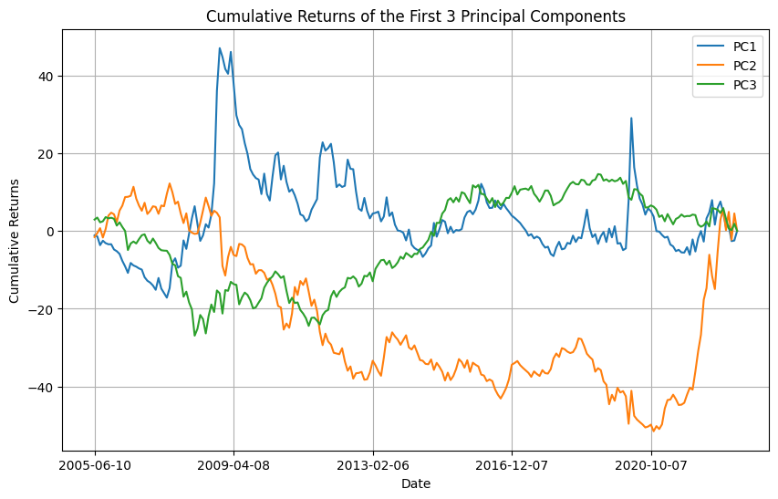

```python
plt.figure(figsize=(10, 6))
scores_cum_df.plot(ax=plt.gca())

plt.title('Cumulative Returns of the First 3 Principal Components')
plt.xlabel('Date')
plt.ylabel('Cumulative Returns')
plt.legend(['PC1', 'PC2', 'PC3'])
plt.grid(True)
plt.show()
```

# • Regress each factors to each of the first 6 components and display the DataFrame:

– Index: the factors

– Columns: the **6** main components

– Content: the **r2** of the regression of the factors vs the components

– What is the factor the best explained by PC1? Display the cumsum of that factor and of **PC1**

– What is the factor the best explained by PC2? Display the cumsum of that factor and of **PC2**

– What is the factor the best explained by PC3? Display the cumsum of that factor and of **PC3**

```python
scores_df6 = pd.DataFrame(
    index=MA_normalised.index,
    columns=loadings_df.columns[:6],
    data=scores[:, :6])

scores_df6
```

|  | PC 1 | PC 2 | PC 3 | PC 4 | PC 5 | PC 6 |
| --- | --- | --- | --- | --- | --- | --- |
| 2005-06-10 | -1.133737 | -1.572122 | 2.913386 | 1.800071 | -0.952150 | 1.095504 |
| 2005-07-06 | -0.273125 | 1.011316 | 0.513141 | -0.494678 | -0.194482 | 0.741023 |
| 2005-08-03 | -2.262779 | 1.264069 | -1.221904 | -1.184977 | -0.465422 | 0.142971 |
| 2005-08-31 | 1.148336 | -2.402257 | 0.266061 | 1.292702 | -0.309005 | -0.321090 |
| 2005-09-27 | -0.629898 | 2.173282 | 1.078671 | -0.380956 | -0.117283 | 0.493546 |
| ... | ... | ... | ... | ... | ... | ... |
| 2022-11-30 | -3.832825 | -5.541734 | -2.716465 | 0.427144 | -1.543457 | -1.404992 |
| 2022-12-28 | 0.324626 | 4.708466 | -2.518250 | -1.657231 | 1.977246 | -1.960790 |
| 2023-01-25 | -3.903745 | -7.180347 | -0.437273 | -2.104131 | -1.428577 | -0.324858 |
| 2023-02-22 | 0.157045 | 6.766788 | 1.664916 | -0.591883 | 0.174767 | 0.060883 |
| 2023-03-22 | 2.468708 | -4.486303 | -1.846562 | 1.076318 | -0.436540 | -1.439897 |

232 rows × 6 columns

```
                               PC1       PC2       PC3       PC4       PC5  \
MSCI World                0.847734  0.018132  0.015373  0.001434  0.011094
S&P 500                   0.791634  0.019967  0.000220  0.001818  0.007687
Euro Stoxx 50             0.747764  0.000497  0.001075  0.001861  0.088351
Euro Stoxx Banks          0.574965  0.017899  0.002831  0.002532  0.120362
CDX.IG 5Y                 0.719317  0.001376  0.011846  0.000010  0.075298
CDX.HY 5Y                 0.779932  0.009609  0.004181  0.007669  0.035685
iTraxx Europe 5Y          0.665570  0.001616  0.022407  0.010025  0.130195
iTraxx Crossover 5Y       0.726087  0.000088  0.016429  0.041374  0.047959
Italy - Germany 10Y       0.104820  0.006027  0.007327  0.004699  0.221695
US 2Y                     0.147492  0.480846  0.083955  0.033085  0.003437
US 5Y                     0.142163  0.702009  0.042211  0.001648  0.000329
US 10Y                    0.108046  0.772846  0.017462  0.004516  0.002325
Germany 2Y                0.144694  0.405909  0.062542  0.074811  0.004935
Germany 5Y                0.109984  0.623796  0.060162  0.066282  0.000839
Germany 10Y               0.082478  0.743492  0.028793  0.021847  0.003587
US B/E Inflation 10Y      0.444796  0.060727  0.040191  0.016170  0.006221
Dollar Index              0.192258  0.054140  0.613654  0.013217  0.002187
EUR/USD                   0.161131  0.023387  0.614468  0.040719  0.004057
USD/JPY                   0.022078  0.314967  0.213099  0.000244  0.002974
Precious Metals           0.065329  0.070289  0.381549  0.005353  0.019842
Industrial Metals         0.352014  0.005616  0.122303  0.021939  0.059225
Crude Oil                 0.223810  0.040065  0.063522  0.016739  0.024498
Agriculture               0.093311  0.032897  0.206967  0.008900  0.116779
S&P 500 1M ATM imp. vol.  0.666423  0.005311  0.005788  0.014132  0.005610
S&P 500 1M 80% imp. vol.  0.506817  0.004585  0.006513  0.021419  0.027947
EUR/USD 3M ATM vol.       0.420580  0.001755  0.019578  0.024658  0.154850
USD/JPY 3M ATM vol.       0.346118  0.007402  0.116504  0.002239  0.144285
AUD/USD 3M ATM vol.       0.575299  0.018893  0.001686  0.010511  0.169019
USD/CAD 3M ATM vol.       0.485170  0.001017  0.047605  0.005852  0.182719
USD 2Y x 2Y ATM vol.      0.047473  0.356244  0.009461  0.378987  0.000768
USD 3M x 10Y ATM vol.     0.277087  0.125866  0.102971  0.130892  0.038537
USD 1Y x 10Y ATM vol.     0.219929  0.240691  0.043299  0.373238  0.004693
USD 5Y x 5Y ATM vol.      0.116821  0.224435  0.009351  0.500718  0.008305
USD 10Y x 20Y ATM vol.    0.152617  0.047261  0.000036  0.340525  0.007533
US Govt.                  0.107920  0.767181  0.028529  0.000090  0.000967
European Govt.            0.000543  0.679288  0.047878  0.076168  0.017870
US Corp. Bonds            0.214779  0.517772  0.004407  0.073595  0.005459
European Corp. Bonds      0.223653  0.377516  0.064352  0.170729  0.007107
US High Yield             0.706725  0.043526  0.001479  0.064874  0.005255
```

[output cut: 29 more lines]

```
USD/JPY 3M ATM vol.       0.034107
AUD/USD 3M ATM vol.       0.025335
USD/CAD 3M ATM vol.       0.089845
USD 2Y x 2Y ATM vol.      0.000007
USD 3M x 10Y ATM vol.     0.006659
USD 1Y x 10Y ATM vol.     0.000139
USD 5Y x 5Y ATM vol.      0.005280
USD 10Y x 20Y ATM vol.    0.033055
US Govt.                  0.007538
European Govt.            0.011189
US Corp. Bonds            0.000060
European Corp. Bonds      0.005140
US High Yield             0.015120
European High Yield       0.003937
Le facteur le mieux expliqué par PC1 est MSCI World avec un R² de 0.8477336350754896
```

[figure not shown]

```
Le facteur le mieux expliqué par PC2 est US 10Y avec un R² de 0.77284584294386
```

[figure not shown]

```
Le facteur le mieux expliqué par PC3 est EUR/USD avec un R² de 0.614468068790962
```

[figure not shown]

```python
r2_df = pd.DataFrame(index=MA_normalised.columns, columns=['PC1', 'PC2', 'PC3', 'PC4', 'PC5', 'PC6'])
for factor in MA_normalised.columns:
    for pc in range(6):
        X = scores_df6.iloc[:, pc]
        X = sm.add_constant(X)
        y = MA_normalised[factor]

        model = sm.OLS(y, X).fit()
        r2_df.at[factor, 'PC' + str(pc+1)] = model.rsquared


r2_df = r2_df.astype(float)
print(r2_df)

for i in range(1, 4):
    pc = 'PC' + str(i)
    best_factor = r2_df[pc].idxmax()
    cumsum_factor = MA_normalised[best_factor].cumsum()
    cumsum_pc = scores_df.iloc[:, i-1].cumsum()
    print(f"Le facteur le mieux expliqué par {pc} est {best_factor} avec un R² de {r2_df.at[best_factor, pc]}")
    plt.figure()
    plt.plot(cumsum_factor, label=f"Cumulative {best_factor}")
    plt.plot(cumsum_pc, label=f"Cumulative {pc}")
    plt.legend()
    plt.title(f"Cumulative Sum of {best_factor} and {pc}")
    plt.xlabel('Date')
    plt.ylabel('Cumulative Sum')
    ax = plt.gca()
    ax.xaxis.set_major_formatter(mdts.DateFormatter('%Y-%m-%d'))
    ax.xaxis.set_major_locator(mdts.AutoDateLocator())
    plt.xticks(rotation=45)
    plt.show()
```

# **Study of the Traditional Assets**

• load the Traditional Assets Multi-asset PCA CHANGES=4w.csv file • Compute the correlation of each assets with PC1 and PC2 • Display the DataFrame:

– Index: Traditional Asset

– Column: PC1 and PC2

– Contains: the correlation between Traditional Asset and the PCs

• Make a scatter plot of the previous DataFrame displaying also the name of the points

```python
AM_pca=pd.read_csv("/content/drive/MyDrive/ESILV/Trading Algo/projet/Traditional Assets_Multi-asset PCA_CHANGES=4w.csv", index_col= 0)
AM_pca
```

|  | US Govt. Bonds | European Govt. Bonds | US IG Corp. Bonds | European IG Corp. Bonds | US High Yield | European High Yield | MSCI World | S&P 500 | Crude Oil | Industrial Metals | Precious Metals |
| --- | --- | --- | --- | --- | --- | --- | --- | --- | --- | --- | --- |
| 2005-06-10 | 0.010386 | 0.017674 | 0.013421 | 0.019308 | 0.029171 | 0.029893 | 0.014866 | 0.024410 | 0.028562 | 0.012891 | 0.005019 |
| 2005-07-06 | 0.001192 | -0.004078 | 0.002829 | -0.002100 | 0.009255 | 0.009683 | 0.003253 | -0.001373 | 0.112833 | -0.011761 | -0.022402 |
| 2005-08-03 | -0.008140 | -0.005336 | -0.004783 | -0.005385 | 0.015161 | 0.014480 | 0.047262 | 0.042098 | -0.020653 | 0.067694 | 0.033755 |
| 2005-08-31 | 0.016193 | 0.015940 | 0.016234 | 0.016116 | 0.003449 | 0.007675 | -0.006708 | -0.018139 | 0.105520 | 0.000730 | -0.027033 |
| 2005-09-27 | -0.011720 | 0.000517 | -0.014359 | -0.000039 | -0.009020 | 0.001002 | 0.011620 | -0.002921 | -0.064567 | 0.019788 | 0.063330 |
| ... | ... | ... | ... | ... | ... | ... | ... | ... | ... | ... | ... |
| 2022-11-30 | 0.026953 | 0.022098 | 0.047535 | 0.025662 | 0.021258 | 0.032360 | 0.086199 | 0.083794 | -0.098184 | 0.092527 | 0.066374 |
| 2022-12-28 | -0.006943 | -0.045961 | -0.006454 | -0.019763 | -0.006197 | -0.008446 | -0.054265 | -0.074297 | -0.023005 | 0.026770 | 0.045765 |
| 2023-01-25 | 0.028097 | 0.030792 | 0.041032 | 0.027126 | 0.035909 | 0.029603 | 0.068924 | 0.060770 | 0.013441 | 0.066096 | 0.052185 |
| 2023-02-22 | -0.025541 | -0.026568 | -0.031878 | -0.012932 | -0.019851 | 0.002439 | -0.008393 | -0.004677 | -0.081716 | -0.072963 | -0.070958 |
| 2023-03-22 | 0.029796 | 0.014531 | 0.023493 | -0.000127 | 0.005266 | -0.009522 | -0.014729 | -0.011974 | -0.045359 | -0.064751 | 0.053697 |

232 rows × 11 columns

```python
AM_pca_normalised = (AM_pca - AM_pca.mean()) / AM_pca.std()
AM_pca_normalised


pca_modelTAM = pca.PCA(data=AM_pca_normalised.values, standardize=True, normalize=False)
loadingsTAM = pca_modelTAM.loadings
scoresTAM = pca_modelTAM.scores
```

```python
scores_df = pd.DataFrame(
    index=AM_pca_normalised.index,
    columns=[f'PC{i+1}' for i in range(2)],
    data=scoresTAM[:, :2]
)

concat = pd.concat([AM_pca_normalised, scores_df], axis=1)
corr_AM = concat.corr().loc[:, ['PC1', 'PC2']].drop(['PC1', 'PC2'], axis=0)
print("Correlation between Traditional Asset and the PCs:\n")
corr_AM.style.format(formatter='{:+.4f}').applymap(func=format_colour)
```

```
Correlation between Traditional Asset and the PCs:
```

|  | PC1 | PC2 |
| --- | --- | --- |
| US Govt. Bonds | -0.0493 | +0.8762 |
| European Govt. Bonds | -0.3228 | +0.8309 |
| US IG Corp. Bonds | -0.7725 | +0.5155 |
| European IG Corp. Bonds | -0.7591 | +0.4755 |
| US High Yield | -0.9218 | -0.1189 |
| European High Yield | -0.8934 | -0.1175 |
| MSCI World | -0.8810 | -0.2469 |
| S&P 500 | -0.8562 | -0.2153 |
| Crude Oil | -0.4175 | -0.5011 |
| Industrial Metals | -0.5941 | -0.4348 |
| Precious Metals | -0.4065 | +0.0328 |

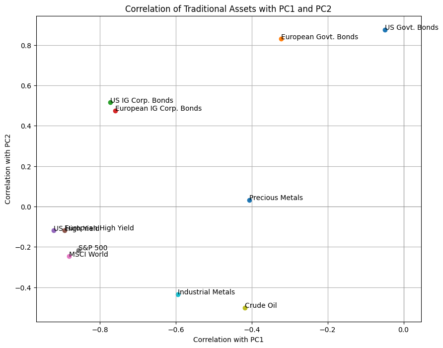

```python
corr_AM = corr_AM.astype(float)
plt.figure(figsize=(10, 8))

for asset in corr_AM.index:
    plt.scatter(corr_AM.loc[asset, 'PC1'], corr_AM.loc[asset, 'PC2'], label=asset)
    plt.text(corr_AM.loc[asset, 'PC1'], corr_AM.loc[asset, 'PC2'], asset)

plt.title('Correlation of Traditional Assets with PC1 and PC2')
plt.xlabel('Correlation with PC1')
plt.ylabel('Correlation with PC2')
plt.grid(True)
plt.axhline(0, color='grey', lw=0.5)
plt.axvline(0, color='grey', lw=0.5)
plt.show()
```

# **Systematic Strategies**

```python
SSM=pd.read_csv("/content/drive/MyDrive/ESILV/Trading Algo/projet/Systematic Strategies_Multi-asset PCA_CHANGES=4w.csv", index_col= 0)
SSM.fillna(0, inplace=True)
SSM.head()
```

|  | Global Quality Income vs. Index | Global Equity Machine Learning | European Value vs. Index | Commodity Congestion | Multi-asset Trend | Repo Carry | Long Rates Vol. | Tail Hedge -SDV | Tail Hedge - SCV | Tail Hedge - Dynamic Put Ratio | Put Spread | Intraday Trend Following | Strong vs. Weak Balance Sheets | FX Carry | FX Value | Short Weekly Tail Puts |
| --- | --- | --- | --- | --- | --- | --- | --- | --- | --- | --- | --- | --- | --- | --- | --- | --- |
| 2005-06-10 | 0.051755 | 0.0 | 0.014358 | 0.024636 | 0.026185 | 0.0 | 0.0 | -0.3152 | 0.0 | 0.0 | -0.005487 | 0.0 | 0.0 | 0.011203 | 0.017098 | 0.0 |
| 2005-07-06 | 0.013968 | 0.0 | 0.008676 | 0.003710 | 0.011092 | 0.0 | 0.0 | -0.9980 | 0.0 | 0.0 | -0.000930 | 0.0 | 0.0 | -0.009567 | 0.019454 | 0.0 |
| 2005-08-03 | -0.045271 | 0.0 | 0.010801 | 0.000871 | -0.003290 | 0.0 | 0.0 | 0.0469 | 0.0 | 0.0 | -0.006943 | 0.0 | 0.0 | 0.005324 | -0.007057 | 0.0 |
| 2005-08-31 | 0.008821 | 0.0 | 0.007892 | 0.002410 | 0.020470 | 0.0 | 0.0 | -0.3767 | 0.0 | 0.0 | 0.002420 | 0.0 | 0.0 | -0.003842 | 0.013888 | 0.0 |
| 2005-09-27 | 0.028851 | 0.0 | -0.004355 | 0.002619 | 0.012372 | 0.0 | 0.0 | -0.5122 | 0.0 | 0.0 | -0.000688 | 0.0 | 0.0 | 0.020388 | 0.008387 | 0.0 |

```python
SSM_normalised = (SSM - SSM.mean()) / SSM.std()
SSM_normalised

pca_modelSSM = pca.PCA(data=SSM_normalised.values, standardize=True, normalize=False)
loadingsSSM = pca_modelSSM.loadings
scoresSSM = pca_modelSSM.scores
```

```python
scoresSSM_df = pd.DataFrame(
    index=SSM_normalised.index,
    columns=[f'PC{i+1}' for i in range(2)],
    data=scoresSSM[:, :2]
)

concatSSM = pd.concat([SSM_normalised, scoresSSM_df], axis=1)
corr_SSM = concatSSM.corr().loc[:, ['PC1', 'PC2']].drop(['PC1', 'PC2'], axis=0)
print("Correlation between Traditional Asset and the PCs:\n")
corr_SSM = corr_SSM.astype(float)
corr_SSM.style.format(formatter='{:+.4f}').applymap(func=format_colour)
```

```
Correlation between Traditional Asset and the PCs:
```

|  | PC1 | PC2 |
| --- | --- | --- |
| Global Quality Income vs. Index | -0.4951 | +0.4387 |
| Global Equity Machine Learning | +0.1352 | +0.1141 |
| European Value vs. Index | +0.6684 | -0.3172 |
| Commodity Congestion | -0.1681 | -0.4705 |
| Multi-asset Trend | -0.4217 | +0.3000 |
| Repo Carry | -0.1262 | -0.6230 |
| Long Rates Vol. | -0.2835 | +0.1945 |
| Tail Hedge -SDV | -0.6480 | -0.4922 |
| Tail Hedge - SCV | -0.4809 | -0.6180 |
| Tail Hedge - Dynamic Put Ratio | -0.8062 | -0.3132 |
| Put Spread | -0.5852 | +0.6196 |
| Intraday Trend Following | -0.7193 | -0.2941 |
| Strong vs. Weak Balance Sheets | -0.5567 | +0.2551 |
| FX Carry | +0.5680 | -0.3548 |
| FX Value | -0.1543 | -0.0678 |
| Short Weekly Tail Puts | -0.1908 | -0.2792 |

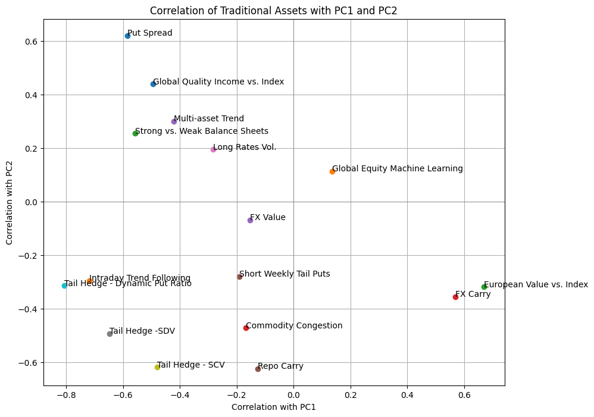

```python
plt.figure(figsize=(10, 8))

for asset in corr_SSM.index:
    plt.scatter(corr_SSM.loc[asset, 'PC1'], corr_SSM.loc[asset, 'PC2'], label=asset)
    plt.text(corr_SSM.loc[asset, 'PC1'], corr_SSM.loc[asset, 'PC2'], asset)

plt.title('Correlation of Traditional Assets with PC1 and PC2')
plt.xlabel('Correlation with PC1')
plt.ylabel('Correlation with PC2')
plt.grid(True)
plt.axhline(0, color='grey', lw=0.5)
plt.axvline(0, color='grey', lw=0.5)
plt.show()
```

# Portfolio Optimization

• load equity factor performance data.csv

• it displays the value of funds based on traditional trading factors

• compute the returns of the fund

• construct the min variance portfolio, display its cumsum return

• At the begining of each month construct a portfolio using

– expected return : past month performance

– long only

– total allocation 1

– cannot trade more than 0.05 per factor

– each factor cannot be allocated more than 0.25

– total trading cannot be more than 0.15

• Display the PnL

• Do the same monthly optimization but this time you can get short and the GMV must be 1

```python
EQ=pd.read_csv("/content/drive/MyDrive/ESILV/Trading Algo/projet/equity_factor_performance_data.csv", index_col= 0)
EQ
```

|  | Growth | Low Risk | Low Size | Momentum | Value | Quality Income |
| --- | --- | --- | --- | --- | --- | --- |
| 2018-09-03 | 3147.275589 | 2521.365122 | 4447.639970 | 7230.019236 | 5367.396587 | 2746.458678 |
| 2018-09-04 | 3147.869877 | 2517.854224 | 4423.624532 | 7240.434396 | 5339.050310 | 2744.511885 |
| 2018-09-05 | 3123.127074 | 2512.737537 | 4432.075319 | 7221.320382 | 5358.611721 | 2765.911701 |
| 2018-09-06 | 3106.574794 | 2518.676856 | 4399.732989 | 7182.130965 | 5311.798170 | 2752.442728 |
| 2018-09-07 | 3101.329324 | 2510.221028 | 4376.879336 | 7139.770025 | 5291.714564 | 2749.406337 |
| ... | ... | ... | ... | ... | ... | ... |
| 2023-08-28 | 4722.945678 | 4272.219410 | 5360.124710 | 11363.308993 | 7459.215794 | 4465.448906 |
| 2023-08-29 | 4806.024404 | 4309.305708 | 5436.687835 | 11535.042889 | 7543.478208 | 4482.673495 |
| 2023-08-30 | 4841.395229 | 4326.786715 | 5465.827827 | 11598.645379 | 7544.416986 | 4483.233991 |
| 2023-08-31 | 4852.078911 | 4308.159090 | 5473.408710 | 11640.134272 | 7521.389497 | 4450.985502 |
| 2023-09-01 | 4884.347114 | 4317.863443 | 5501.348987 | 11709.032625 | 7570.535386 | 4448.521921 |

1305 rows × 6 columns

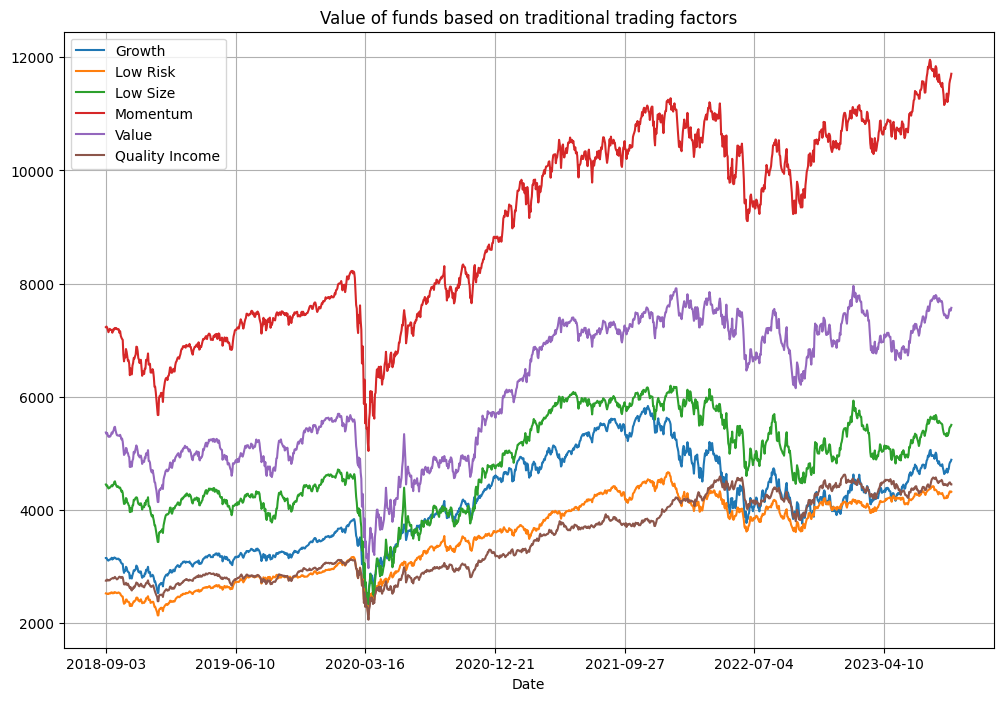

```python
plt.figure(figsize=(12, 8))
EQ.plot(ax=plt.gca())
plt.title('Value of funds based on traditional trading factors')
plt.xlabel('Date')
plt.grid(True)
plt.show()
```

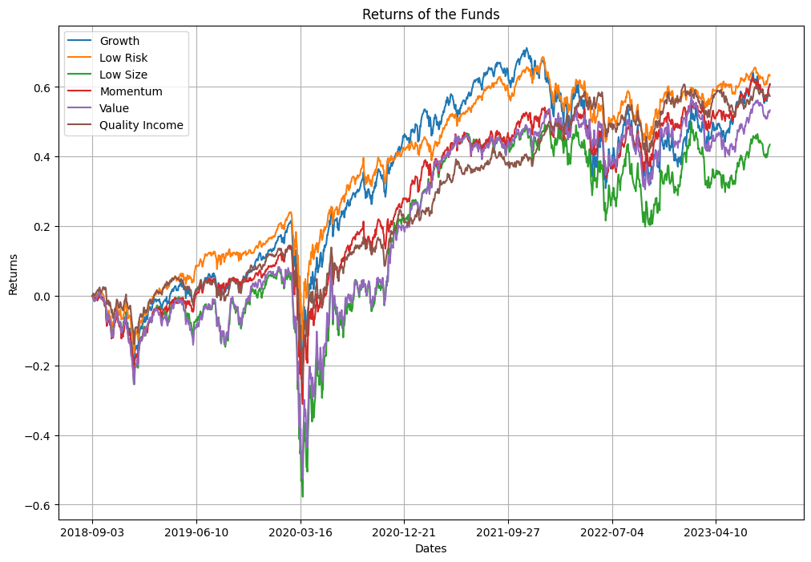

```python
returns_EQ = EQ.pct_change()
returns_EQ
returns_EQ.fillna(0, inplace=True)
cumsum_returns_EQ = returns_EQ.cumsum()

plt.figure(figsize=(12,8))
cumsum_returns_EQ.plot(ax=plt.gca())
plt.title('Returns of the Funds')
plt.xlabel('Dates')
plt.ylabel('Returns')
plt.grid(True)
plt.show()
```